# Lab 3: Classification

PSTAT 131/231

## Introduction

This lab will be our first experience with classification models. These models differ from the regression model we saw in the last chapter by the fact that the response variable is a qualitative variable instead of a continuous variable. This chapter will use [‘parsnip’](https://www.tidymodels.org/start/models/) for model fitting and [‘recipes and workflows’](https://www.tidymodels.org/start/recipes/) to perform the transformations.

### Loading Packages

We load `tidymodels` for modeling functions, `ISLR` and `ISLR2` for data sets, `discrim` to give us access to discriminant analysis models such as LDA and QDA, as well as the Naive Bayes model, and `poissonreg` for Poisson regression. Finally, we load `corrr` for aid in visualizing correlation matrices.

```r
library(tidymodels)
library(ISLR) # For the Smarket data set
library(ISLR2) # For the Bikeshare data set
library(discrim)
library(poissonreg)
library(corrr)
library(corrplot)
library(klaR) # for naive bayes
tidymodels_prefer()
```

### Data

We’ll start out by working with the `Smarket` data set for this lab, which contains daily percentage returns for the S&P 500 stock index between 2001 and 2005. It contains 1,250 observations on 8 numeric variables, plus a factor variable called `Direction` which has two levels, “Up” and “Down”.

Before we go on to modeling, we’ll explore the data a little, at least to look at possible correlations between the variables. `Direction` is our outcome variable of interest; we’ll attempt to predict it using the volume of shares traded (`Volume`) and the five lag variables (which represent the percentage return for the previous days).

#### Activities

- Access the help page for `Smarket`. What does the `Direction` variable represent? What predictors do you think might be correlated with it?

To look at correlations among the continuous variables, we’ll try using the `corrr` package. The `correlate()` function will calculate the correlation matrix between all the variables that it is given. We choose to remove `Direction,` it is not numeric. Then we pass the results to `rplot()` to visualize the correlation matrix.

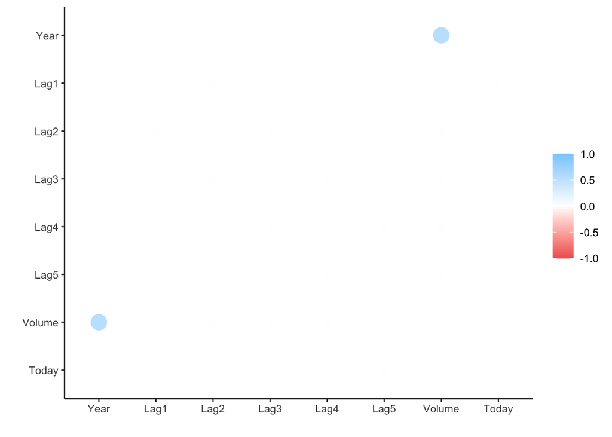

```r
cor_Smarket <- Smarket %>%
  select(-Direction) %>%
  correlate()
rplot(cor_Smarket)
```

#### Activities

- What do you notice from this correlation matrix?
- Do you need to worry about predictors being highly linearly correlated with each other?
- Does this matrix tell you anything about relationships between predictors and the outcome?

We could also use `ggplot` and the `geom_tile()` function to create a heatmap-style correlation plot, with a few more lines of code:

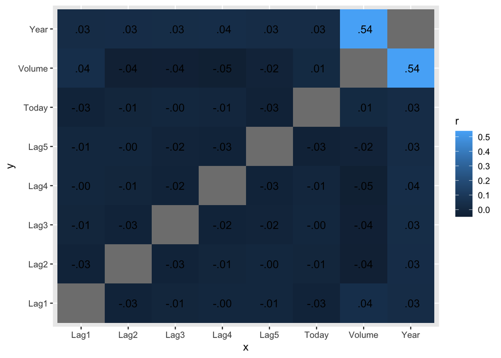

```r
cor_Smarket %>%
  stretch() %>%
  ggplot(aes(x, y, fill = r)) +
  geom_tile() +
  geom_text(aes(label = as.character(fashion(r))))
```

Or we could use the function from a previous lab, `corrplot()`:

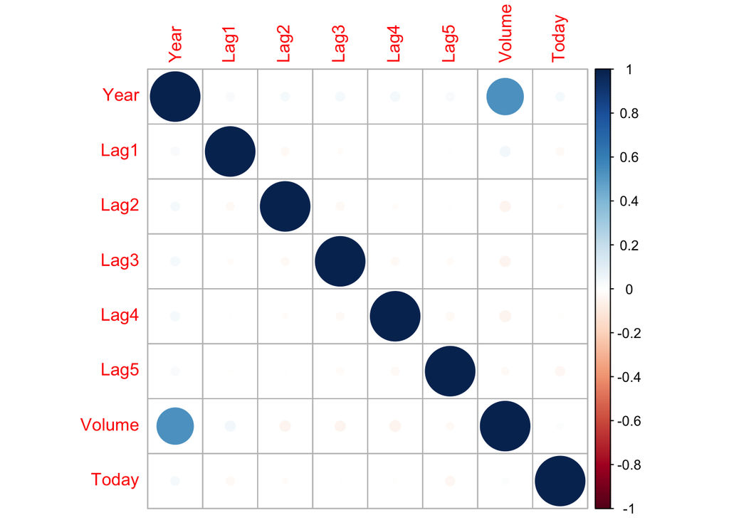

```r
Smarket %>%
  select(-Direction) %>%
  cor() %>%
  corrplot()
```

Notice that the upper and lower triangles of the matrix are identical; that’s a common feature of correlation matrices. Again, we see that only `Year` and `Volume` have much of any correlation with each other, and it’s only about $0.54$.

Let’s investigate that correlation a little further. Here’s a boxplot of `Volume` by `Year`:

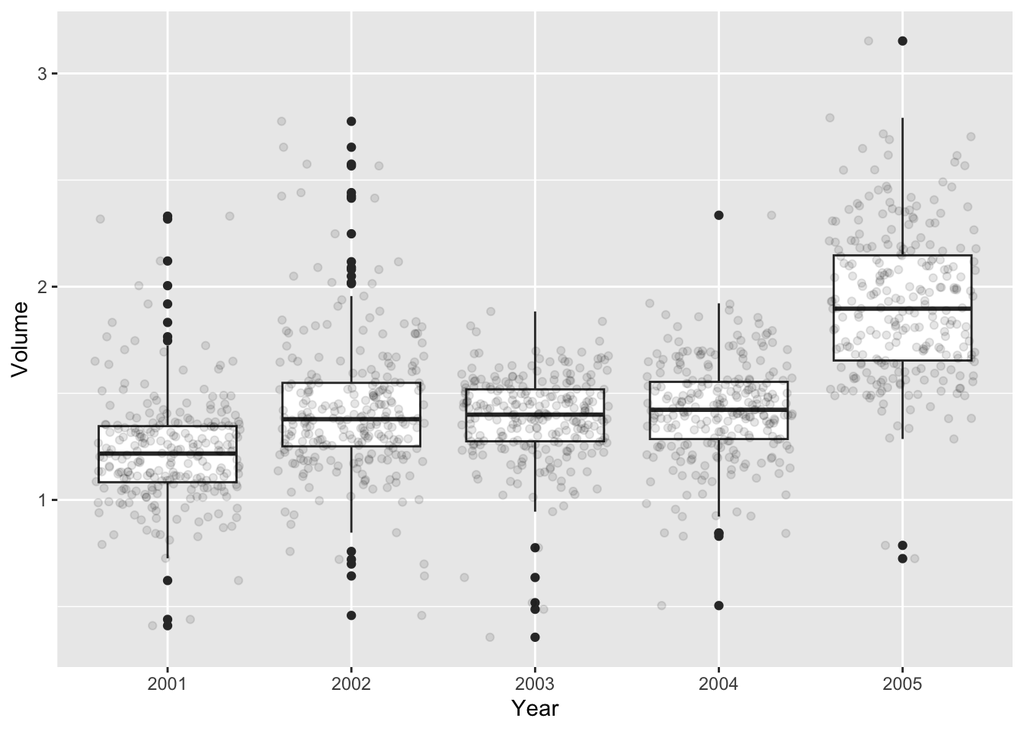

```r
ggplot(Smarket, aes(factor(Year), Volume)) +
  geom_boxplot() +
  geom_jitter(alpha = 0.1) +
  xlab("Year")
```

#### Activities

- Describe the relationship between `Year` and `Volume`.

Lastly, it’s worth looking at the distribution of our outcome variable.

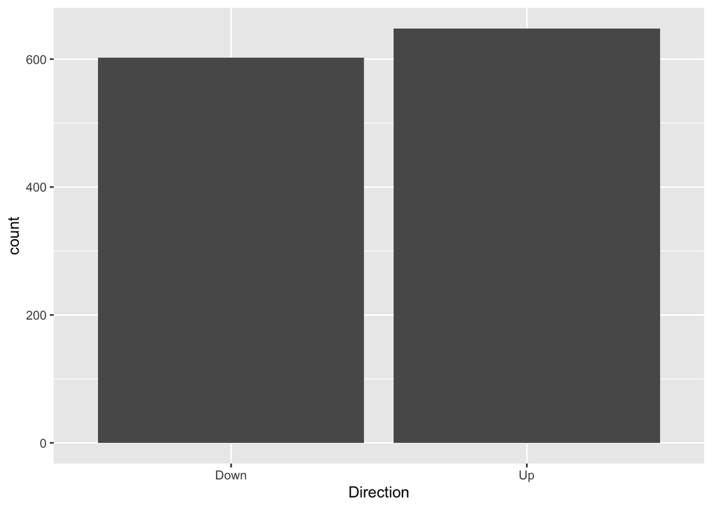

```r
Smarket %>%
  ggplot(aes(x = Direction)) +
  geom_bar()
```

When we’re working with a categorical outcome, we are often interested in whether the levels of our outcome are *balanced*, meaning whether the count of observations at one level is approximately equal to the count at the other level(s).

```r
Smarket %>%
  select(Direction) %>%
  table()
```

```
## Direction
## Down   Up
##  602  648
```

Here, there are 602 `Down` observations and 648 `Up`. These aren’t exactly equal, but this data set is fairly balanced. We can probably safely assume that this minor difference in counts won’t affect model performance.

We’ll split the data, stratifying on the outcome, `Direction`. Stratifying on the outcome ensures that the proportion of observations with each level of the outcome will be approximately the same for each random sample, training and testing.

```r
set.seed(3435)

smarket_split <- initial_split(Smarket, prop = 0.70,
                                strata = Direction)
smarket_train <- training(smarket_split)
smarket_test <- testing(smarket_split)
```

## Logistic Regression

### Creating a Recipe

First, just as with our linear regression lab last week, we want to create a recipe to represent the model we’ll be fitting.

```r
smarket_recipe <- recipe(Direction ~ Lag1 + Lag2 + Lag3 + Lag4 +
                           Lag5 + Volume, data = smarket_train)
```

### Specifying an Engine

Then, again like last week, we specify the model type and engine:

```r
log_reg <- logistic_reg() %>%
  set_engine("glm") %>%
  set_mode("classification")
```

### Workflow

We set up the workflow and fit the model to the training data:

```r
log_wkflow <- workflow() %>%
  add_model(log_reg) %>%
  add_recipe(smarket_recipe)

log_fit <- fit(log_wkflow, smarket_train)
```

### Model Results

We can view the results:

```r
log_fit %>%
  tidy()
```

```
## # A tibble: 7 × 5
##   term        estimate std.error statistic p.value
##   <chr>          <dbl>     <dbl>     <dbl>   <dbl>
## 1 (Intercept) -0.197      0.293    -0.672    0.502
## 2 Lag1        -0.00479    0.0601   -0.0797   0.937
## 3 Lag2        -0.0537     0.0619   -0.868    0.386
## 4 Lag3         0.00265    0.0611    0.0435   0.965
## 5 Lag4        -0.0440     0.0594   -0.740    0.459
## 6 Lag5         0.0381     0.0605    0.630    0.529
## 7 Volume       0.184      0.193     0.952    0.341
```

#### Activities

- Are any of the predictors statistically significant?

### Assessing Model Performance

We can use the model to generate probability predictions for the training data:

```r
predict(log_fit, new_data = smarket_train, type = "prob")
```

```
## # A tibble: 874 × 2
##    .pred_Down .pred_Up
##         <dbl>    <dbl>
##  1      0.521    0.479
##  2      0.470    0.530
##  3      0.498    0.502
##  4      0.498    0.502
##  5      0.467    0.533
##  6      0.518    0.482
##  7      0.468    0.532
##  8      0.478    0.522
##  9      0.517    0.483
## 10      0.521    0.479
## # … with 864 more rows
```

Each row represents the probability predicted by the model that a given observation belongs to a given class. Notice this is redundant, because one could be calculated directly from the other, but it’s useful in multiclass situations.

However, it’s more useful to summarize the predicted values. We can use `augment()` to attach the predicted values to the daata, then generate a confusion matrix:

```r
augment(log_fit, new_data = smarket_train) %>%
  conf_mat(truth = Direction, estimate = .pred_class)
```

```
##           Truth
## Prediction Down  Up
##       Down  104  98
##       Up    317 355
```

Or we can create a visual representation of the confusion matrix:

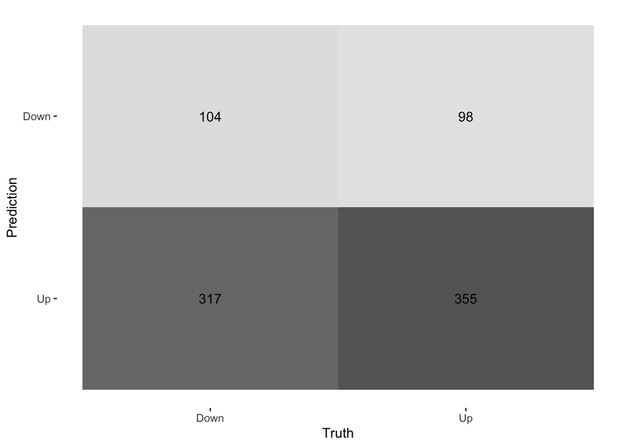

```r
augment(log_fit, new_data = smarket_train) %>%
  conf_mat(truth = Direction, estimate = .pred_class) %>%
  autoplot(type = "heatmap")
```

#### Activities

- What do you notice from the confusion matrix?
- Does the model tend to overpredict one class or the other? If so, which one?
- Do you think the model is doing well? Why or why not?

Let’s calculate the accuracy of this model, or the average number of correct predictions it made on the **training** data. This is the model’s **training error rate**.

```r
log_reg_acc <- augment(log_fit, new_data = smarket_train) %>%
  accuracy(truth = Direction, estimate = .pred_class)
log_reg_acc
```

```
## # A tibble: 1 × 3
##   .metric  .estimator .estimate
##   <chr>    <chr>          <dbl>
## 1 accuracy binary         0.525
```

We will now go on to fit three more models to the **training** data: A linear discriminant analysis (LDA) model, a quadratic discriminant analysis (QDA) model, and a naive Bayes model.

## LDA

The beauty of `tidymodels` is that we only need to set up the recipe once. Then fitting any number of additional model classes can be done with only a few lines of code:

```r
lda_mod <- discrim_linear() %>%
  set_mode("classification") %>%
  set_engine("MASS")

lda_wkflow <- workflow() %>%
  add_model(lda_mod) %>%
  add_recipe(smarket_recipe)

lda_fit <- fit(lda_wkflow, smarket_train)
```

### Assessing Performance

This can be done almost exactly the same way:

```r
predict(lda_fit, new_data = smarket_train, type = "prob")
```

```
## # A tibble: 874 × 2
##    .pred_Down .pred_Up
##         <dbl>    <dbl>
##  1      0.521    0.479
##  2      0.470    0.530
##  3      0.498    0.502
##  4      0.498    0.502
##  5      0.467    0.533
##  6      0.518    0.482
##  7      0.468    0.532
##  8      0.478    0.522
##  9      0.517    0.483
## 10      0.520    0.480
## # … with 864 more rows
```

We can view a confidence matrix and calculate accuracy on the **training data**:

```r
augment(lda_fit, new_data = smarket_train) %>%
  conf_mat(truth = Direction, estimate = .pred_class)
```

```
##           Truth
## Prediction Down  Up
##       Down  103  98
##       Up    318 355
```

```r
lda_acc <- augment(lda_fit, new_data = smarket_train) %>%
  accuracy(truth = Direction, estimate = .pred_class)
lda_acc
```

```
## # A tibble: 1 × 3
##   .metric  .estimator .estimate
##   <chr>    <chr>          <dbl>
## 1 accuracy binary         0.524
```

#### Activities

- Compare the results of the LDA model to the results of the logistic regression model.

## QDA

Again, fitting any number of additional model classes can be done with only a few lines of code:

```r
qda_mod <- discrim_quad() %>%
  set_mode("classification") %>%
  set_engine("MASS")

qda_wkflow <- workflow() %>%
  add_model(qda_mod) %>%
  add_recipe(smarket_recipe)

qda_fit <- fit(qda_wkflow, smarket_train)
```

### Assessing Performance

And again:

```r
predict(qda_fit, new_data = smarket_train, type = "prob")
```

```
## # A tibble: 874 × 2
##    .pred_Down .pred_Up
##         <dbl>    <dbl>
##  1      0.395    0.605
##  2      0.453    0.547
##  3      0.472    0.528
##  4      0.485    0.515
##  5      0.436    0.564
##  6      0.424    0.576
##  7      0.461    0.539
##  8      0.462    0.538
##  9      0.473    0.527
## 10      0.507    0.493
## # … with 864 more rows
```

We can view a confidence matrix and calculate accuracy on the **training data**:

```r
augment(qda_fit, new_data = smarket_train) %>%
  conf_mat(truth = Direction, estimate = .pred_class)
```

```
##           Truth
## Prediction Down  Up
##       Down  125  99
##       Up    296 354
```

```r
qda_acc <- augment(qda_fit, new_data = smarket_train) %>%
  accuracy(truth = Direction, estimate = .pred_class)
qda_acc
```

```
## # A tibble: 1 × 3
##   .metric  .estimator .estimate
##   <chr>    <chr>          <dbl>
## 1 accuracy binary         0.548
```

## Naive Bayes

Finally, we’ll fit a Naive Bayes model to the **training data**. For this, we will be using the `naive_bayes()` function to create the specification and set the `usekernel` argument to `FALSE`. This means that we are assuming that the predictors are drawn from Gaussian distributions.

```r
nb_mod <- naive_Bayes() %>%
  set_mode("classification") %>%
  set_engine("klaR") %>%
  set_args(usekernel = FALSE)

nb_wkflow <- workflow() %>%
  add_model(nb_mod) %>%
  add_recipe(smarket_recipe)

nb_fit <- fit(nb_wkflow, smarket_train)
```

### Assessing Performance

And again:

```r
predict(nb_fit, new_data = smarket_train, type = "prob")
```

```
## # A tibble: 874 × 2
##    .pred_Down .pred_Up
##         <dbl>    <dbl>
##  1      0.474    0.526
##  2      0.447    0.553
##  3      0.449    0.551
##  4      0.460    0.540
##  5      0.462    0.538
##  6      0.460    0.540
##  7      0.483    0.517
##  8      0.477    0.523
##  9      0.495    0.505
## 10      0.495    0.505
## # … with 864 more rows
```

We can view a confidence matrix and calculate accuracy on the **training data**:

```r
augment(nb_fit, new_data = smarket_train) %>%
  conf_mat(truth = Direction, estimate = .pred_class)
```

```
##           Truth
## Prediction Down  Up
##       Down  107  98
##       Up    314 355
```

```r
nb_acc <- augment(nb_fit, new_data = smarket_train) %>%
  accuracy(truth = Direction, estimate = .pred_class)
nb_acc
```

```
## # A tibble: 1 × 3
##   .metric  .estimator .estimate
##   <chr>    <chr>          <dbl>
## 1 accuracy binary         0.529
```

## Comparing Model Performance

Now we can make a table of the accuracy rates from these four models to choose the model that produced the highest accuracy on the training data:

```r
accuracies <- c(log_reg_acc$.estimate, lda_acc$.estimate,
                nb_acc$.estimate, qda_acc$.estimate)
models <- c("Logistic Regression", "LDA", "Naive Bayes", "QDA")
results <- tibble(accuracies = accuracies, models = models)
results %>%
  arrange(-accuracies)
```

```
## # A tibble: 4 × 2
##   accuracies models
##        <dbl> <chr>
## 1      0.548 QDA
## 2      0.529 Naive Bayes
## 3      0.525 Logistic Regression
## 4      0.524 LDA
```

#### Activities

- Which model performed the best on the training data?
- Which model would you choose? Why?

## Fitting to Testing Data

In future weeks, we’ll cover how to use cross-validation to get an estimate of our models’ performance on *testing data* and use that estimate for selecting a model instead. We choose based on training accuracy here because we haven’t discussed cross-validation yet. Choosing a model based on training performance is *not a good idea in general*.

Since we’ve chosen a model – naive Bayes – we can view its confusion matrix using the **testing** data:

```r
augment(nb_fit, new_data = smarket_test) %>%
  conf_mat(truth = Direction, estimate = .pred_class)
```

```
##           Truth
## Prediction Down  Up
##       Down   50  55
##       Up    131 140
```

We can also look at its **testing** accuracy. Here, we add two other metrics, sensitivity and specificity, out of curiosity:

```r
multi_metric <- metric_set(accuracy, sensitivity, specificity)

augment(nb_fit, new_data = smarket_test) %>%
  multi_metric(truth = Direction, estimate = .pred_class)
```

```
## # A tibble: 3 × 3
##   .metric     .estimator .estimate
##   <chr>       <chr>          <dbl>
## 1 accuracy    binary         0.505
## 2 sensitivity binary         0.276
## 3 specificity binary         0.718
```

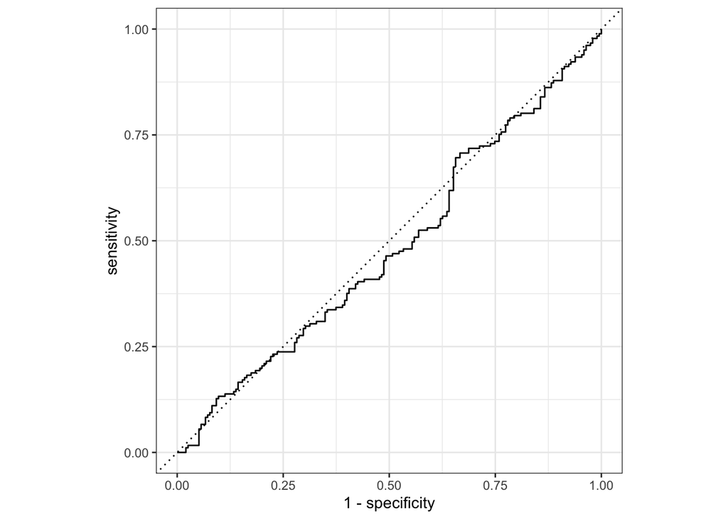

```r
augment(lda_fit, new_data = smarket_test) %>%
  roc_curve(Direction, .pred_Down) %>%
  autoplot()
```

#### Activities

- What do the sensitivity and specificity values mean? Interpret them in terms of the concepts and data.
- How well did the model perform on the **testing** data?
- Why do you think the model performed like it did?

## Resources

The free book [Tidy Modeling with R](https://www.tmwr.org/) is strongly recommended.

## Source

Several parts of this lab come directly from the [“ISLR Tidymodels Labs”](https://emilhvitfeldt.github.io/ISLR-tidymodels-labs/classification.html). Credit to Emil Hvitfeldt for writing and maintaining the open-source book.